# Voting for the Radical Right in Germany: A First Bayesian Model

Pr(rightvote | worker) — priors, prior predictive checks, and a simple hierarchical-free logistic model

Author

Affiliation

Armin Schäfer

Johannes Gutenberg University

**Note**

**Status: superseded by the pipeline.** After checking the fitted model against this notebook’s specification, the sample was narrowed further to the 2017 and 2021 elections only, and to voters only (dropping non-voters rather than folding them into “not radical right”). That finalized specification now lives in `R/functions_clean.R` (`clean_ess_ger_simple()`) and `R/functions_model.R` (`fit_model_ger_simple()`), run via `_targets.R` (`targets::tar_make()`, then `targets::tar_read(model_ger_simple)`). This notebook is kept as the record of *how* the priors were derived and checked (still valid) and of the exploratory `btw >= 2013`, population-based sample this model started from (superseded, not wrong) — it is not the canonical version of the model going forward.

# 1 Purpose and scope

This notebook develops the *first, deliberately simple* Bayesian model in the “from Bayes’ rule to Bayesian estimation” workflow (see `ANALYSIS_PLAN.md`): a single-country (Germany), non-hierarchical logistic regression of voting for the radical right on worker status, with age, gender, immigrant background, and union membership as controls. The substantive focus is the posterior for `Pr(rightvote | worker)` versus `Pr(rightvote | non-worker)` — the model-based, covariate-adjusted analogue of the manuscript’s closed-form Alford Index (`icv()` in `R/functions_derive.R`).

This is a **descriptive/associational** model: `worker` is an observed occupational-class status, not a randomized treatment, so the coefficient on `worker` should be read as an adjusted association net of age, gender, immigrant background, and union membership — not a causal effect of “being a worker” on vote choice.

Recoding logic here is exploratory (per `scripts/` convention); once settled, it should move into `R/functions_clean.R` (`clean_ess()`) and `R/functions_model.R` (replacing the `fit_model_pooled()` stub), and this model becomes a `_targets.R` target rather than living only in this notebook.

# 2 Data and variable construction

```r
ess <- readRDS(here("data", "processed", "essger.rds"))
nrow(ess)
```

```
[1] 28547
```

## 2.1 Outcome: `rightvote`

The cleaned data provide `pvote_non_voter`, a party-choice variable that already recodes non-voters into their own `"nonvoter"` category rather than leaving them as `NA` (as plain `pvote` does). We use this population-based coding — matching the manuscript’s own framing of loyalty/contribution as shares of the *population*, not just of voters — so `rightvote` compares radical-right voters against everyone else, voters and non-voters alike. A voters-only version of this model (dropping non-voters from the sample) is a natural robustness check but is not the primary specification here.

```r
ess <- ess |>
  mutate(
    rightvote = case_when(
      is.na(pvote_non_voter) ~ NA_real_,
      as.character(pvote_non_voter) == "radical right" ~ 1,
      TRUE ~ 0
    )
  )

count(ess, rightvote)
```

```
# A tibble: 2 × 2
  rightvote     n
      <dbl> <int>
1         0 27838
2         1   709
```

## 2.2 Focal predictor: `worker`

`class5` is a five-category class scheme (Higher-grade service class / Lower-grade service class / Small business / Skilled workers / Low-skilled workers) derived upstream in `data/processed/class_scheme.rds` from detailed occupational coding. Following Alford’s (and Oesch’s) definition of the manual working class, `worker` combines the two manual-worker categories:

```r
ess <- ess |>
  mutate(
    worker = case_when(
      is.na(class5) ~ NA_real_,
      class5 %in% c(4, 5) ~ 1,   # Skilled workers, Low-skilled workers
      TRUE ~ 0                    # Higher/Lower-grade service class, Small business
    )
  )

count(ess, worker, class5fac)
```

```
# A tibble: 6 × 3
  worker class5fac                      n
   <dbl> <fct>                      <int>
1      0 Small business              1345
2      0 Lower-grade service class   5372
3      0 Higher-grade service class  5340
4      1 Low-skilled workers         2998
5      1 Skilled workers             8974
6     NA <NA>                        4518
```

## 2.3 A critical restriction: pre-2013 elections had (almost) no radical-right vote

The AfD was founded in 2013 and did not enter the Bundestag until 2017; earlier German radical-right parties (Republikaner, NPD, DVU) polled far below the threshold this coding scheme picks up. Pooling all eleven ESS rounds (2002–2021) would silently mix elections in which “voting radical right” was barely a live option with elections in which it was a major choice — an identifying assumption that must be made explicit, not buried in a pooled average:

```r
ess |>
  group_by(btw) |>
  summarise(n = n(), pct_rightvote = round(100 * mean(rightvote, na.rm = TRUE), 2))
```

```
# A tibble: 6 × 3
    btw     n pct_rightvote
  <dbl> <int>         <dbl>
1  2002  4535          0
2  2005  4460          0
3  2009  4601          0
4  2013  4683          3.84
5  2017  8442          5.22
6  2021  1826          4.82
```

Rightvote is exactly (or essentially) zero for 2002–2009. We therefore restrict this first model to the AfD-era elections, 2013 onward. This drops roughly half the sample but avoids building a model on three elections in which the outcome was structurally impossible.

```r
ess_afd_era <- ess |> filter(btw >= 2013)
nrow(ess_afd_era)
```

```
[1] 14951
```

## 2.4 Reference categories and missingness

```r
ess_afd_era <- ess_afd_era |>
  mutate(
    age_grp = factor(age_grp, levels = c("18-29", "30-65", "66+")),
    gender  = factor(gender,  levels = c("female", "male"))
  )

analysis_vars <- c("rightvote", "worker", "age_grp", "gender", "immigrant", "union")

n_before <- nrow(ess_afd_era)
ess_model <- ess_afd_era |>
  drop_na(all_of(analysis_vars))
n_after <- nrow(ess_model)

tibble(
  n_before_listwise_deletion = n_before,
  n_after = n_after,
  pct_dropped = round(100 * (1 - n_after / n_before), 1)
)
```

```
# A tibble: 1 × 3
  n_before_listwise_deletion n_after pct_dropped
                       <int>   <int>       <dbl>
1                      14951   13058        12.7
```

Reference categories: `worker = 0` (non-worker), `age_grp = "18-29"`, `gender = "female"`, `immigrant = 0`, `union = 0`. Missingness is concentrated in `class5`/`worker` (occupational class is unavailable for respondents outside the labour force); listwise deletion is a simplification worth revisiting with multiple imputation once the model specification is settled, but is acceptable for this first pass.

# 3 Exploratory look at the focal contrast

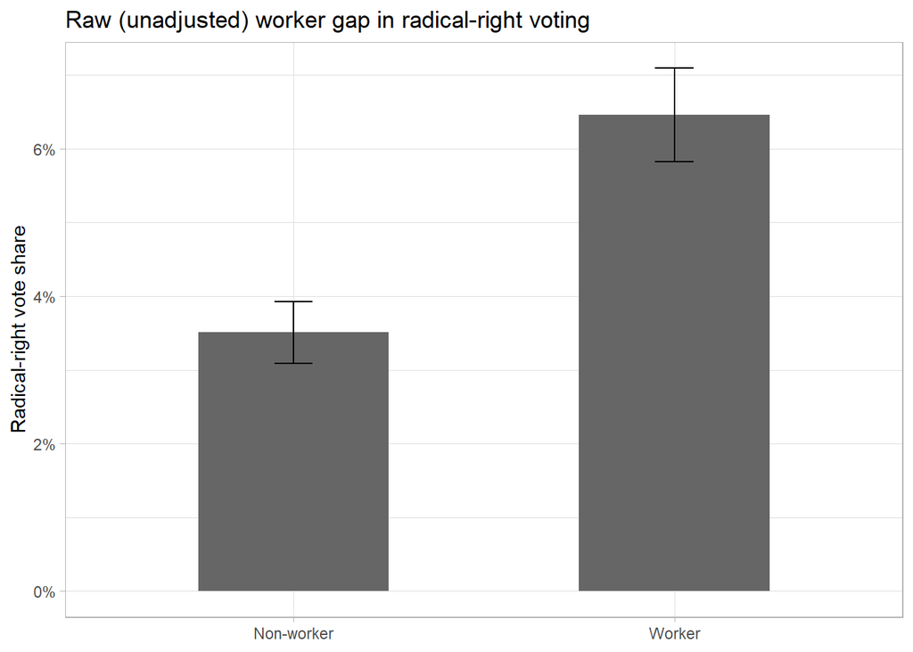

Figure 1: Radical-right vote share by worker status, Germany 2013-2021 (raw sample proportions, unadjusted for other covariates).

```r
eda_worker <- ess_model |>
  group_by(worker) |>
  summarise(
    n = n(),
    p_rightvote = mean(rightvote),
    se = sqrt(p_rightvote * (1 - p_rightvote) / n)
  ) |>
  mutate(worker_lab = factor(worker, levels = c(0, 1), labels = c("Non-worker", "Worker")))

ggplot(eda_worker, aes(x = worker_lab, y = p_rightvote)) +
  geom_col(width = 0.5, fill = "grey40") +
  geom_errorbar(aes(ymin = p_rightvote - 1.96 * se, ymax = p_rightvote + 1.96 * se), width = 0.1) +
  scale_y_continuous(labels = scales::percent_format(accuracy = 1)) +
  labs(
    x = NULL, y = "Radical-right vote share",
    title = "Raw (unadjusted) worker gap in radical-right voting"
  ) +
  theme_light()
```

This raw gap (roughly 3.5% vs. 6.5%, i.e. an unadjusted difference of about 3 percentage points, or an odds ratio of about 1.9) is the empirical benchmark the priors below are checked against — priors are not fit to this number, but should not rule it out a priori.

# 4 The model

$$\text{rightvote}_i \sim \text{Bernoulli}(p_i)$$
$$\text{logit}(p_i) = \alpha + \beta_{\text{worker}} \cdot \text{worker}_i +
\beta_{\text{age30-65}} \cdot \text{age30-65}_i + \beta_{\text{age66+}} \cdot \text{age66+}_i +
\beta_{\text{male}} \cdot \text{male}_i + \beta_{\text{immigrant}} \cdot \text{immigrant}_i +
\beta_{\text{union}} \cdot \text{union}_i$$

No group-level (multilevel) structure is included at this stage: single country, and the goal is a deliberately simple baseline before adding country/round structure (see `ANALYSIS_PLAN.md`, models M1–M2). We use brms’s `0 + Intercept` parameterization so that `alpha` is the literal log-odds for the reference respondent (young, non-worker, female, non-immigrant, non-union) rather than brms’s default internally-centered intercept — this keeps the Intercept prior directly interpretable.

## 4.1 Priors

[output not shown]

```r
model_formula <- bf(rightvote ~ 0 + Intercept + worker + age_grp + gender + immigrant + union)

model_priors <- c(
  prior(normal(-3, 1), class = "b", coef = "Intercept"),
  prior(normal(0, 0.5), class = "b")
)
```

## 4.2 Prior predictive check

Before fitting to real outcomes, two checks: a fast analytic simulation (no Stan compilation needed, useful for quickly trying alternative prior widths), then the canonical brms `sample_prior = "only"` check against the actual model/data structure.

### 4.2.1 Analytic check

```r
set.seed(2026)
n_sim <- 20000

alpha     <- rnorm(n_sim, -3, 1)
b_worker  <- rnorm(n_sim, 0, 0.5)
b_age3065 <- rnorm(n_sim, 0, 0.5)
b_age66p  <- rnorm(n_sim, 0, 0.5)
b_male    <- rnorm(n_sim, 0, 0.5)
b_immig   <- rnorm(n_sim, 0, 0.5)
b_union   <- rnorm(n_sim, 0, 0.5)

p_reference   <- plogis(alpha)
p_worker      <- plogis(alpha + b_worker)
p_max_combo   <- plogis(alpha + b_worker + b_age3065 + b_male + b_immig + b_union)
icv_prior     <- p_worker - p_reference

qs <- function(x) round(quantile(x, c(.025, .25, .5, .75, .975)), 4)

tibble(
  quantity = c(
    "Pr(rightvote) at reference cell",
    "Pr(rightvote | worker=1, else reference)",
    "Pr(rightvote) at a maximal covariate combination",
    "Prior-predictive worker contrast (ICV-like)"
  )
) |>
  bind_cols(
    map_dfr(list(p_reference, p_worker, p_max_combo, icv_prior), ~ as_tibble_row(qs(.x)))
  ) |>
  gt() |>
  fmt_number(columns = -quantity, decimals = 3)
```

| quantity | 2.5% | 25% | 50% | 75% | 97.5% |
| --- | --- | --- | --- | --- | --- |
| Pr(rightvote) at reference cell | 0.007 | 0.025 | 0.048 | 0.090 | 0.266 |
| Pr(rightvote \| worker=1, else reference) | 0.006 | 0.023 | 0.048 | 0.097 | 0.316 |
| Pr(rightvote) at a maximal covariate combination | 0.003 | 0.018 | 0.048 | 0.122 | 0.490 |
| Prior-predictive worker contrast (ICV-like) | −0.064 | −0.011 | 0.000 | 0.017 | 0.111 |

```r
cat("P(reference-cell Pr(rightvote) > 0.5):", mean(p_reference > 0.5), "\n")
```

```
P(reference-cell Pr(rightvote) > 0.5): 0.0016
```

```r
cat("P(maximal-combination Pr(rightvote) > 0.5):", mean(p_max_combo > 0.5), "\n")
```

```
P(maximal-combination Pr(rightvote) > 0.5): 0.0238
```

```r
cat("P(prior-predictive worker contrast > 0):", mean(icv_prior > 0), "\n")
```

```
P(prior-predictive worker contrast > 0): 0.50275
```

The prior-predictive worker contrast is centered at essentially zero (`P(contrast > 0) ≈ 0.5`) with a 95% interval comfortably spanning the raw sample gap (~+3 points) in both directions — the prior is not pre-judging the sign or size of the worker effect. Implausible predictions (>50% radical right vote share) get well under 3% of prior mass even at the most AfD-favorable covariate combination.

### 4.2.2 Canonical brms check

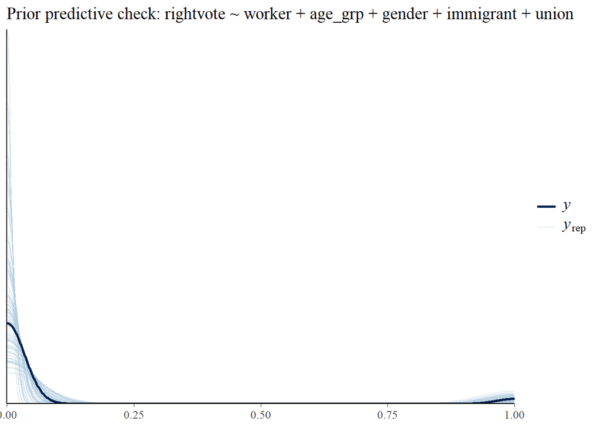

```r
fit_prior_only <- brm(
  formula = model_formula,
  data    = ess_model,
  family  = bernoulli(),
  prior   = model_priors,
  sample_prior = "only",
  chains = 4, cores = 4, iter = 2000, seed = 2026,
  file = here("models", "m_ger_simple_prior_only")
)

pp_check(fit_prior_only, ndraws = 100) +
  labs(title = "Prior predictive check: rightvote ~ worker + age_grp + gender + immigrant + union")
```

## 4.3 Fitting the model

```r
fit <- brm(
  formula = model_formula,
  data    = ess_model,
  family  = bernoulli(),
  prior   = model_priors,
  chains = 4, cores = 4, iter = 2000, seed = 2026,
  file = here("models", "m_ger_simple")
)
```

## 4.4 Diagnostics

```r
summary(fit)
posterior::summarise_draws(fit, "rhat", "ess_bulk", "ess_tail")

pp_check(fit, ndraws = 100)
pp_check(fit, type = "stat_grouped", group = "worker", stat = "mean")
```

Check before interpreting anything below: all `Rhat < 1.01`, bulk- and tail-ESS comfortably above ~400 per parameter, and the grouped posterior predictive check shows the model reproducing the observed radical-right vote share within each worker group reasonably well. Do not proceed past this point on the basis of this notebook’s code alone — inspect the actual numbers and plots yourself.

# 5 Focal result: Pr(rightvote | worker)

```r
worker_contrast <- avg_predictions(
  fit,
  variables = "worker",
  type = "response"
)
worker_contrast
```

[output not shown]

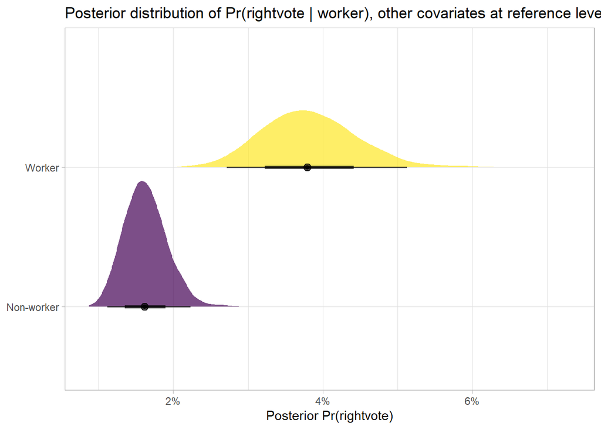

```r
# `add_epred_draws()` builds its prediction from every population-level
# predictor in the model, so `newdata` must supply all of them -- unlike
# `re_formula = NA` (which only drops *group-level* terms, none of which
# exist in this flat model), there is no way to omit age_grp/gender/
# immigrant/union here. We hold them at their reference levels explicitly,
# including the *unused* factor levels (via `levels = levels(ess_model$...)`)
# so brms reconstructs the same dummy-coded columns it was fitted on --
# a factor built from a single string without this would silently produce
# a 1-level factor and break the model matrix.
newdata_worker <- tibble(
  worker    = c(0, 1),
  age_grp   = factor("18-29", levels = levels(ess_model$age_grp)),
  gender    = factor("female", levels = levels(ess_model$gender)),
  immigrant = 0,
  union     = 0
)

worker_draws <- newdata_worker |>
  add_epred_draws(fit, re_formula = NA) |>
  ungroup()

worker_draws |>
  mutate(worker_lab = factor(worker, levels = c(0, 1), labels = c("Non-worker", "Worker"))) |>
  ggplot(aes(x = .epred, y = worker_lab, fill = worker_lab)) +
  stat_halfeye(alpha = 0.7) +
  scale_x_continuous(labels = scales::percent_format(accuracy = 1)) +
  scale_fill_viridis_d(guide = "none") +
  labs(
    x = "Posterior Pr(rightvote)", y = NULL,
    title = "Posterior distribution of Pr(rightvote | worker), other covariates at reference levels"
  )+
  theme_light()
```

```r
posterior_icv <- worker_draws |>
  select(.draw, worker, .epred) |>
  pivot_wider(names_from = worker, values_from = .epred, names_prefix = "p_worker") |>
  mutate(posterior_icv = p_worker1 - p_worker0)

posterior_icv |>
  summarise(
    median = median(posterior_icv),
    q025 = quantile(posterior_icv, .025),
    q975 = quantile(posterior_icv, .975),
    p_gt_0 = mean(posterior_icv > 0)
  )
```

```
# A tibble: 1 × 4
  median   q025   q975 p_gt_0
   <dbl>  <dbl>  <dbl>  <dbl>
1 0.0216 0.0146 0.0309      1
```

`worker_contrast` and `posterior_icv` answer a related but distinct question and should not be reported interchangeably: `worker_contrast` (via `avg_predictions()`) is the *average marginal effect* of `worker`, averaged over the observed sample distribution of age/gender/immigrant/ union; `posterior_icv` is the effect for one specific, fixed covariate profile (young, female, non-immigrant, non-union). They will normally be close but need not be identical, particularly if `worker` is unevenly distributed across the other covariates (e.g. if workers skew male).

`posterior_icv` is the covariate-adjusted, fully Bayesian analogue of the manuscript’s closed-form `icv()`: instead of one point estimate from a raw 2x2 table, it is a full posterior distribution of the worker/non-worker gap in `Pr(rightvote)`, net of age, gender, immigrant background, and union membership. Report it as median + 95% credible interval, and note `p_gt_0` — the posterior probability that the adjusted worker effect is positive — rather than reducing it to a single point estimate with a p-value.

# 6 Next steps

- Restrict to voters only. Done: `clean_ess_ger_simple()` drops non-voters (`pvote == NA`) instead of folding them into “not radical right”.
- Once satisfied with the specification, move `rightvote`/`worker` construction into `R/functions_clean.R` and this model into `R/functions_model.R`, and add both as `_targets.R` targets. Done — see the status note at the top of this notebook. The sample was also narrowed from `btw >= 2013` to `btw %in% c(2017, 2021)` in the process.
- Run `targets::tar_make()` (Stan toolchain required for `model_ger_simple`) and inspect `targets::tar_read(model_ger_simple)`’s diagnostics (`summary()`, `pp_check()`, Rhat/ESS) before trusting any posterior result from it.
- Sensitivity check: refit with `beta_worker ~ Normal(0, 0.25)` and `Normal(0, 1)` and confirm the posterior conclusion about `p_gt_0` is not an artifact of the SD = 0.5 choice (ANALYSIS_PLAN.md, §7) — a good use of `tar_target()`’s branching, or just a manual second call to `fit_model_ger_simple()` with an adjusted prior argument.
- Extend to the multilevel model sequence in `ANALYSIS_PLAN.md` (M1/M2) once ready to move beyond a single country.
- Consider formalizing `scripts/process_ess_ger*.qmd` (which build `essger.rds` from raw ESS + the class scheme) into `R/` functions and targets too, so the whole pipeline — not just this model — is `tar_make()`-reproducible from raw ESS data.